# chapter01

EricDoug

2014年11月24日

# 第一章 引论

本章将从广泛的应用领域，介绍一些时间序列的实例。时间序列及其模型的一个独特的性质是，通常我们不能假定观测值独立取自同一总体（例如，取均值不能的总体），时间序列分析的要点是研究具有相关性质的模型。

## 1.1 时间序列举例

**洛杉矶年降水量**

```r
library(ggplot2)
library(TSA)
```

```
## locfit 1.5-9.1    2013-03-22
##
##
```

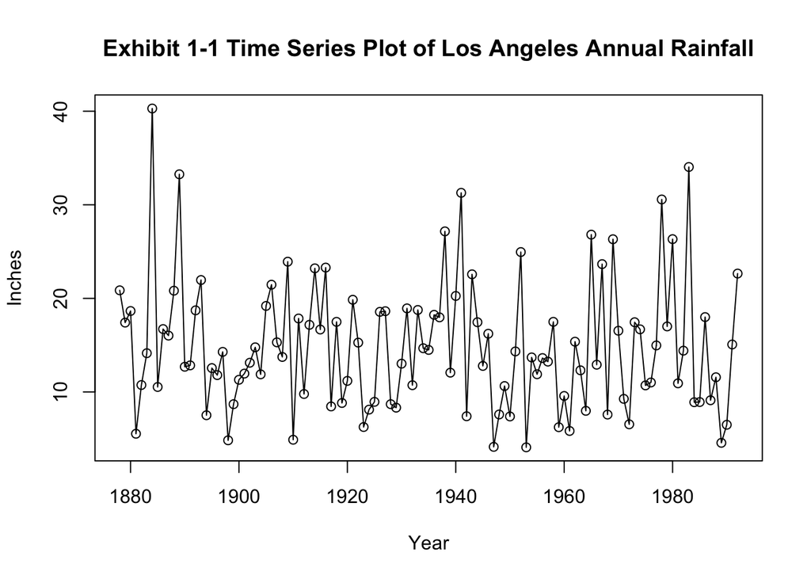

```r
#加载指定的数据集
data(larain)
plot(larain,ylab = "Inches",xlab = 'Year',type = 'o',main="Exhibit 1-1 Time Series Plot of Los Angeles Annual Rainfall")
```

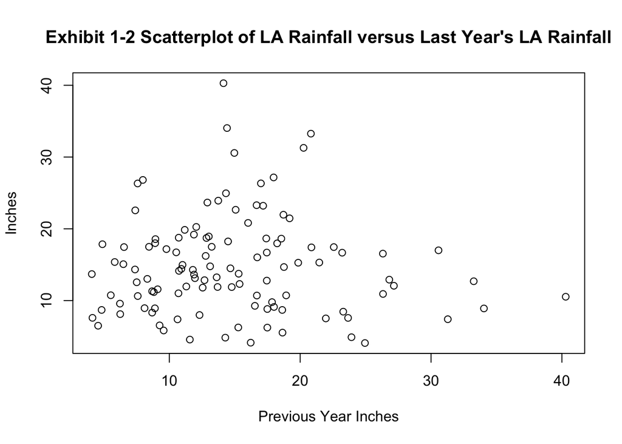

```r
plot(y=larain,x=zlag(larain),ylab='Inches',xlab='Previous Year Inches',main="Exhibit 1-2 Scatterplot of LA Rainfall versus Last Year's LA Rainfall")
```

> 图表1-2是由此绘出的降水量散点图。例如，右下角的点显示降水量非常大的1883年40英寸的降水量，其后1884年降水量中等（约12英寸）,图中靠近顶部的点表明40英寸降水量的年份，其上一年降水量比较典型，大约15英寸。

该图给人的主要印象是当年降水量与去年降水量几乎没有什么联系，既无“趋势”，也没有一般倾向。上一年与当年降水量的相关性非常小，从预测和建模的角度，这样的时间序列没有研究意义。

**化工过程**

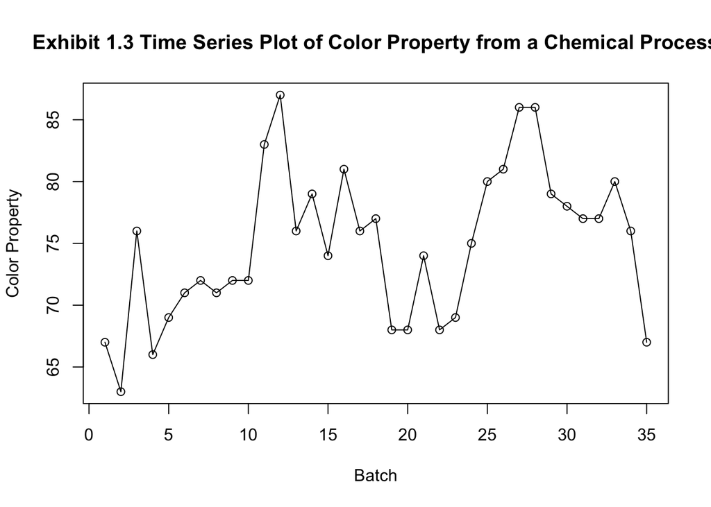

```r
data(color)
plot(color,ylab='Color Property',xlab='Batch',type='o',main='Exhibit 1.3 Time Series Plot of Color Property from a Chemical Process')
```

图表1-3 是颜色值的时间序列图。表示连续批次颜色的属性。

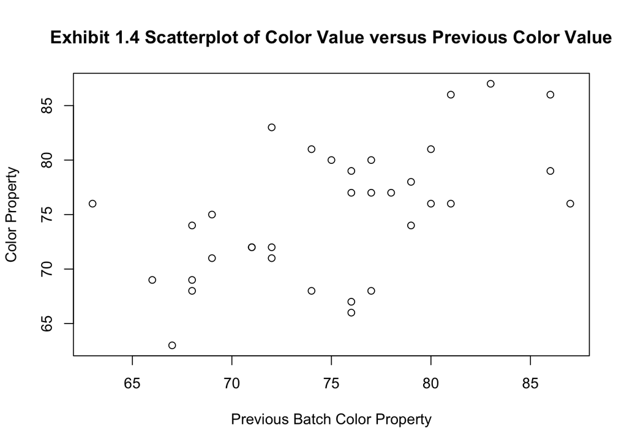

```r
plot(y=color,x=zlag(color),ylab='Color Property',xlab='Previous Batch Color Property',main='Exhibit 1.4 Scatterplot of Color Value versus Previous Color Value')
```

图表1-4是相邻颜色值的散点图。该图显示了一个稍微向上的趋势————数值较小后面的批次趋于较小的值，中等值后面的批次趋于中等值，数值较大后面的批次趋于较大的值。该趋势明显但并不非常强烈，例如，散点图的相关系数约为0.6。

**滤油器月销售量**

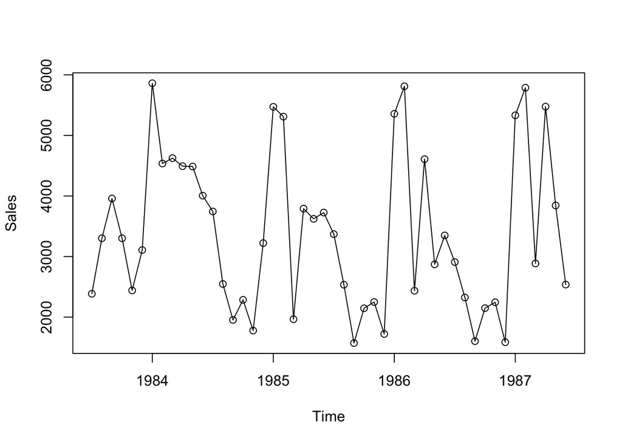

```r
data(oilfilters)
plot(oilfilters,type='o',ylab='Sales')
```

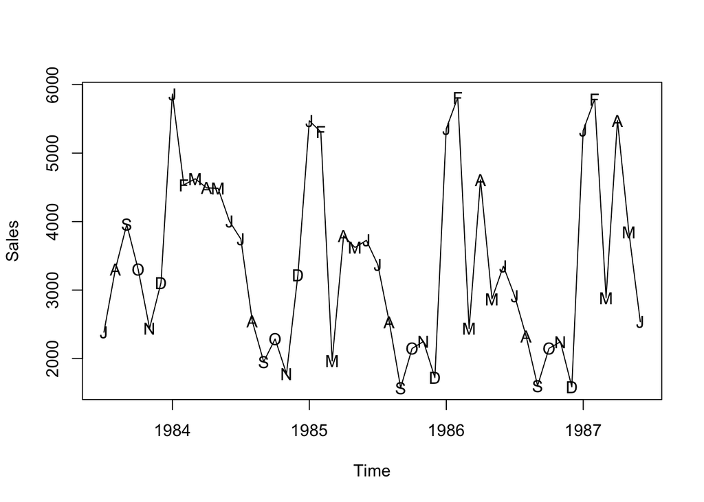

```r
plot(oilfilters,type='l',ylab='Sales')
points(y=oilfilters,x=time(oilfilters),pch=as.vector(season(oilfilters)))
```